# 20220128

Takala

条件付き確率の分かりやすい（あるいはパラドキシカルな）例として， 乳がん検査の偽陽性の話題がよく取り上げられる．

私自身この話題を知ったときは，確率の不思議を知った感じがした． そのため人に説明することも多い．

今回は以下のスライドの例をお借りしてまとめてみる．

**[法と統計学 第5回 ベイズの定理(1)](http://park18.wakwak.com/~mdai/courses/lawstat/05.pdf)**

状況設定は次の通りだ：

> 乳がんの早期発見のため，特定の年齢に達した女性は自覚症状がなくても定期的に検査を受けることが推奨されている． あなたが医師として，ある地域でこのような乳がんの検査を実施するとする．この地域で乳がんの検査に参加する自覚症状のない女性について，以下のことがわかっている．
> - [1] 女性の1人が本当に乳がんである確率は0.8%
> - [2] 本当に乳がんであれば，検査結果が陽性になる確率は90%．
> - [3] ただし乳がんでなくても，陽性と出る確率は5%

> このとき，検査で陽性とされた女性が本当に乳がんである確率はどれくらいか？

多くの人は，「検査の精度は90％，間違うのはたった5%．そんな優秀な検査で陽性とでているのだから，高確率で乳がんのはず．．．」 と思うのではないだろうか．

実際はどうだろうか．確かめてみよう． 数学的にはベイズの定理をごにょごにょすれば良いが，今はより直観的な頻度主義な説明を採用しよう．

具体的には女性1万人を対象に， 問題文に提示されている確率に従うと，どのくらいの人がどのくらいの状況になるか 樹形図を用いて整理してみる．

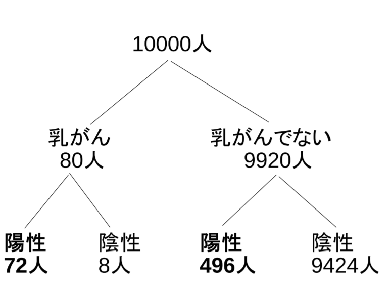

樹形図

要点は次の通り：

- まず[1]より，10000人のうち80人が本当に乳がんである．残りの9920人は乳がんではない．
- 続いて[2]より「本当に乳がんで検査結果が陽性になる人」は，80×90％=72人いる．残りの8人は本当に乳がんだけど検査結果は陰性になる．
- 最後に[3]より「乳がんでないのに検査結果が陽性になる人」は，9920×5％=496人いる．残りの9424人は乳がんでもないし検査結果も陰性である人々である．

さて，このように整理してみると，検査結果が陽性になる人は72+496=568人である．その中で本当に乳がんであるのは72人なので，求める確率は72/568=0.13=13％ということになる．

つまり検査結果が陽性だったして，本当に乳がんである確率は13％ほどということになる．最初に抱いた直観とは少し異なるのではないだろうか．

もちろん，ここで提示した数字はすべて架空のものである． しかし現実にこの問題の状況と同じようなことは多々ある．

なんだか精度の良い検査で陽性になってしまったからといって， 必要以上に絶望しなくて良いことも多々ある．

確率は人類にはかなり難しい概念であるので，扱うときは注意深くなる必要が大切である． また，このような難しさを利用し，嘘のない範囲で巧みに都合の良い数字のみを提示するような人々も存在する．

世渡りするには最低限の確率リテラシーを身に付けておく必要がある．